# AutoEncoder

- AutoEncoder is a type of neural network where the output layer has the same dimensionality as the input layer.
- An autoencoder replicates the data from the input to the output in an unsupervised manner and is therefore sometimes referred to as a replicator neural network.
- **Applications**
  - Data Compression
  - Image Denoising
  - Dimensionality Reduction
  - Feature Extraction
  - Image Generation
  - Image Colorisation

## Importing Libraries

```python
!pip3 install sewar -q
```

```python
import PIL
import time
import glob
import sewar
import IPython
import imageio
import numpy as np
import tensorflow as tf
import tensorflow_probability as tfp
from tqdm.notebook import tqdm

import matplotlib.pyplot as plt
%matplotlib inline
```

## Loading the Dataset

```python
(x_train, y_train), (x_test, y_test) = tf.keras.datasets.mnist.load_data()
```

```python
print('X-train:', x_train.shape)
print('Y-train:', y_train.shape)
print('X-test: ', x_test.shape)
print('Y-test: ', y_test.shape)
```

```
X-train: (60000, 28, 28)
Y-train: (60000,)
X-test:  (10000, 28, 28)
Y-test:  (10000,)
```

- We will not be needing Y_labels for our model.

## Normalizing the Images

```python
x_train = x_train/255.
x_test = x_test/255.
```

## Customizing the Dimensons

- Tensor format: (batch_size, height, width, depth)

```python
x_train = np.expand_dims(x_train, 3).astype(np.float32)
x_test = np.expand_dims(x_test, 3).astype(np.float32)
```

```python
flat_x_train = x_train.reshape(x_train.shape[0], x_train.shape[1]*x_train.shape[2]*x_train.shape[3]).astype(np.float32)
flat_x_test = x_test.reshape(x_test.shape[0], x_test.shape[1]*x_test.shape[2]*x_test.shape[3]).astype(np.float32)
```

## Functions for later use

```python
def visual_results(x, y, n, cmap=None, size=None):
    '''
        Input: x => list of original images
               y => list of generated images
               n => number of images of each x & y to display
               cmap => colormap
               size => plot figure dimensions
        Output: displaying images based on inputs
    '''

    plt.figure(figsize=size)
    for i in range(n):
        plt.subplot(2, n, i+1)
        plt.imshow(np.squeeze(x[i], axis=2), cmap=cmap)
        plt.xticks(ticks=[])
        plt.yticks(ticks=[])
        plt.title(label='Real'+str(i+1))

        plt.subplot(2, n, n+i+1)
        plt.imshow(np.squeeze(y[i], axis=2), cmap=cmap)
        plt.xticks(ticks=[])
        plt.yticks(ticks=[])
        plt.title(label='Generated'+str(i+1))
```

```python
def plot_result(history, components=['loss', 'val_loss'], colors=['b','r'], labels=['Training loss', 'Validation loss']):
    '''
        Input: history => model training information
               component => element of data
               color => color to be used for plotting
               label => text for defining plots
        Output: plot of data component
    '''

    plt.figure(figsize=(20, 6))
    for component, color, label in zip(components, colors, labels):
        plt.plot(history.history[component], marker='o', color=color, label=label)
        plt.title('Loss')
        plt.legend()
        plt.xticks(history.epoch)
        for x, y in zip(history.epoch, history.history[component]):
            label = "{:.2f}".format(y)
            plt.annotate(label,                               # this is the text
                         (x, y),                              # this is the point to label
                         textcoords="offset points",          # how to position the text
                         xytext=(0, 5),                       # distance from text to points (x,y)
                         ha='center')                         # horizontal alignment can be left, right or center
```

```python
def metrics(x, y):
    '''
        Input: x => list of reference images
               y => list of generated images
        Output: Avg. MSE => ranges from [0, inf) => should be low;
                Avg. SSIM => ranges from [-1, 1] => should be high;
                Avg. UQI => ranges from [0, 1] => should be high
    '''

#     try:
#         mx = np.iinfo(x[0].dtype).max
#     except:
#         mx = np.finfo(x[0].dtype).max
#     mse, ssim, uqi = [], [], []

    mse, uqi = [], []
    for i, j in zip(x, y):
        mse.append(sewar.full_ref.mse(GT=i, P=j))
#         ssim.append(sewar.full_ref.ssim(GT=i, P=j, ws=11, K1=0.01, K2=0.03, MAX=mx, mode='valid'))
        uqi.append(sewar.full_ref.uqi(GT=i, P=j, ws=8))

    print('Mean Squared Error (MSE) =', np.mean(mse))
#     print('Structural Similarity Index (SSIM) =', np.mean(ssim))
    print('Universal Image Quality Index (UQI) =', np.mean(uqi))
```

```python
def visual_categorization(x, y):
    '''
        Input: x => (nx2) dimension data - for x & y axis resp.
               y => different labels for color
        Output: Scatter plot of input-data
    '''

    plt.figure(figsize=(10, 8))
    plt.scatter(x=x[:, 0], y=x[:, 1], c=y)
    plt.colorbar()
```

```python
def model_plot(model, name):
    '''
        Input: model => Object of TensorFlow Model
               name => name of file to save (without extention)
        Output: Graph of model architecture
    '''
    return tf.keras.utils.plot_model(
        model=model,
        to_file=name+'.png',
        show_shapes=True,
        show_layer_names=True,
        expand_nested=True,
        dpi=96
    )
```

## Defining some HyperParameters

```python
train_size = x_train.shape[0]
test_size = x_test.shape[0]
batch_size = 32
train_batch_size = train_size//batch_size
test_batch_size = test_size//batch_size
epochs = 10
learning_rate = 0.001
intermediate_dim = 2   # so that it can be visualized
high_intermediate_dim = 800
```

## Types of AutoEncoders

- All these AutoEncoders are built in different ways for exploring.
- These ways are **NOT** specific to any type of AutoEncoder

### Vanilla AutoEncoder

- In its simplest form, the autoencoder is a three layers net, i.e. a neural net with one hidden layer.
- On the basis of number of units in hidden layer, it can be further classified as-
  - **UnderComplete AutoEncoder**: less units in hidden layer than input/output layer
  - **OverComplete AutoEncoder**: more units in hidden layer than input/output layer
- The input and output are the same, and we learn how to reconstruct the input, for example using the adam optimizer and the mean squared error loss function.
- This can be extended by multiple hidden layers (i.e, **Multilayer AutoEncoder**)

[figure not shown]

#### Defining Model

```python
class VanillaAutoEncoder(tf.keras.Model):
    '''Vanilla AutoEncoder Architecture'''

    def __init__(self, intermediate_dim, original_dim):
        '''
            Input: intermediate_dim => Bottleneck Dimension
                   original_dim => Input Dimension
            Output: It creates the architecture based on inputs
        '''

        super(VanillaAutoEncoder, self).__init__(name='VanillaAutoEncoder')

        self.encoder = tf.keras.Sequential([
            tf.keras.Input(shape=original_dim, name='EncoderInput', dtype='float32'),
            tf.keras.layers.Dense(units=intermediate_dim, activation='relu', name='EncoderOutput', dtype='float32')
        ], name='Encoder')

        self.decoder = tf.keras.Sequential([
            tf.keras.Input(shape=intermediate_dim, name='DecoderInput', dtype='float32'),
            tf.keras.layers.Dense(units=original_dim, activation='sigmoid', name='DecoderOutput', dtype='float32')
        ], name='Decoder')

        super(VanillaAutoEncoder, self).build((None, original_dim))


    def call(self, input_features):
        '''
            Feeds input-data to the model architecture
        '''
        input_features = tf.cast(input_features, dtype='float32')
        coded_features = self.encoder(input_features)
        reconstructed = self.decoder(coded_features)
        return reconstructed
```

#### Defining Loss Function

```python
def model_loss(model, original):
    '''
        Returns loss defined for the model
    '''
    reconstruction_error = tf.reduce_mean(tf.square(tf.subtract(model(original), tf.cast(original, dtype='float32'))))
    return reconstruction_error
```

#### Defining Training Process

```python
@tf.function
def train_model(loss, model, optimizer, original):
    '''
        Trains the model by computing loss and gradients
    '''
    with tf.GradientTape() as tape:
        gradients = tape.gradient(loss(model, original), model.trainable_variables)
        gradient_variables = zip(gradients, model.trainable_variables)
        optimizer.apply_gradients(gradient_variables)
```

#### Defining Optimizer

```python
opt = tf.optimizers.Adam(learning_rate=learning_rate)
```

#### Preparing Data for Model

```python
train_dataset = (tf.data.Dataset.from_tensor_slices(flat_x_train).shuffle(train_size).batch(batch_size))
test_dataset = (tf.data.Dataset.from_tensor_slices(flat_x_test).shuffle(test_size).batch(batch_size))
```

#### Initializing Model

```python
autoencoder = VanillaAutoEncoder(intermediate_dim=intermediate_dim, original_dim=flat_x_train.shape[-1])
autoencoder.summary()
```

```
Model: "VanillaAutoEncoder"
_________________________________________________________________
Layer (type)                 Output Shape              Param #
=================================================================
Encoder (Sequential)         (None, 2)                 1570
_________________________________________________________________
Decoder (Sequential)         (None, 784)               2352
=================================================================
Total params: 3,922
Trainable params: 3,922
Non-trainable params: 0
_________________________________________________________________
```

```python
autoencoder.encoder.summary()
```

```
Model: "Encoder"
_________________________________________________________________
Layer (type)                 Output Shape              Param #
=================================================================
EncoderOutput (Dense)        (None, 2)                 1570
=================================================================
Total params: 1,570
Trainable params: 1,570
Non-trainable params: 0
_________________________________________________________________
```

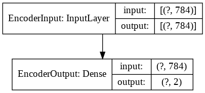

```python
model_plot(model=autoencoder.encoder, name='VanillaAutoEncoder-Encoder')
```

```python
autoencoder.decoder.summary()
```

```
Model: "Decoder"
_________________________________________________________________
Layer (type)                 Output Shape              Param #
=================================================================
DecoderOutput (Dense)        (None, 784)               2352
=================================================================
Total params: 2,352
Trainable params: 2,352
Non-trainable params: 0
_________________________________________________________________
```

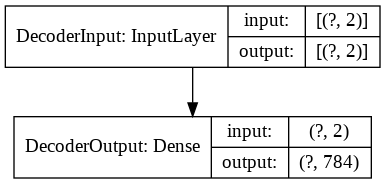

```python
model_plot(model=autoencoder.decoder, name='VanillaAutoEncoder-Decoder')
```

#### Training Model

```python
for epoch in range(epochs):
    start = time.time()
    for step, batch_input in tqdm(enumerate(train_dataset), desc='Epoch - '+str(epoch+1), total=train_batch_size):
        train_model(loss=model_loss, model=autoencoder, optimizer=opt, original=batch_input)
    end = time.time()

    print('Loss:', float(model_loss(model=autoencoder, original=batch_input)), end='\t')
    print('Time-Elapsed:', (end-start))
```

```
Loss: 0.057587772607803345	Time-Elapsed: 9.683584213256836
```

```
Loss: 0.06120937317609787	Time-Elapsed: 3.435225486755371
```

```
Loss: 0.05896230787038803	Time-Elapsed: 3.302161931991577
```

```
Loss: 0.05249720811843872	Time-Elapsed: 3.4185245037078857
```

```
Loss: 0.05735368654131889	Time-Elapsed: 3.268101930618286
```

```
Loss: 0.04945119470357895	Time-Elapsed: 3.252734422683716
```

```
Loss: 0.05541390925645828	Time-Elapsed: 3.2551462650299072
```

```
Loss: 0.05306908115744591	Time-Elapsed: 3.300405502319336
```

```
Loss: 0.05493951216340065	Time-Elapsed: 3.371835231781006
```

```
Loss: 0.05931892246007919	Time-Elapsed: 3.3206067085266113
```

```python
# If this is used, we can ignore loss, train functions & data generated as batches
# As they all are managed by TensorFlow's fit method

# autoencoder.compile(optimizer='adam', loss='mse')
# history1 = autoencoder.fit(
#     x=flat_x_train,
#     y=flat_x_train,
#     epochs=epochs,
#     batch_size=batch_size,
#     steps_per_epoch=train_batch_size,
#     validation_data=(flat_x_test, flat_x_test),
#     validation_steps=test_batch_size,
#     shuffle=True
# )
```

#### Testing Model

```python
pred1 = autoencoder.predict(flat_x_test).reshape(x_test.shape)
pred1.shape
```

```
(10000, 28, 28, 1)
```

```python
metrics(x=x_test, y=pred1)
```

```
Mean Squared Error (MSE) = 0.05560344681014545
Universal Image Quality Index (UQI) = 0.49534110605250325
```

#### Visualizing Results

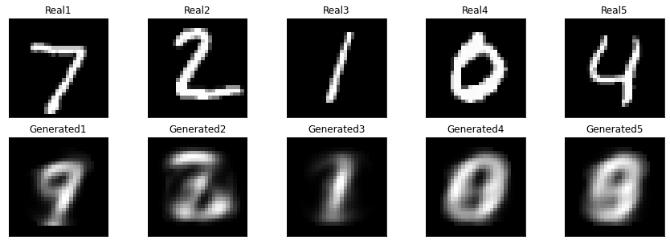

```python
visual_results(x=x_test, y=pred1, n=5, cmap='gray', size=(15, 5))
```

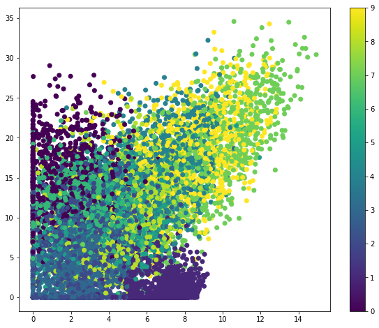

```python
visual_categorization(x=autoencoder.encoder.predict(flat_x_test), y=y_test)
```

#### Encoder-Decoder

```python
embeddings = autoencoder.encoder.predict(flat_x_test)
embeddings.shape
```

```
(10000, 2)
```

```python
output = autoencoder.decoder.predict(embeddings)
output.shape
```

```
(10000, 784)
```

```python
output = output.reshape(x_test.shape)
output.shape
```

```
(10000, 28, 28, 1)
```

### Convolutional AutoEncoder (CAE)

- CAE learn to encode the input image into a set of simple features and then reconstruct the input from them.
- In this type of autoencoder, encoder layers are known as convolution layers and decoder layers are also called deconvolution layers. The deconvolution side is also known as upsampling or transpose convolution.

[figure not shown]

- The model architecture is the same as **Vanilla AutoEncoder** architecture.
- But, instead of just Dense layers, **Conv layers** are also used.

#### Defining Model

```python
class ConvolutionAutoEncoder:
    '''Convolutional AutoEncoder Architecture'''

    @staticmethod
    def build(latent_dim, original_dim, filters=(32, 64)):
        '''
            Input: latent_dim => Bottleneck Dimension
                   original_dim => Input Dimension
                   filters => list of filters for Conv2D layer
            Output: It creates the architecture based on inputs
        '''

        # define the input to the encoder
        encoder_input = tf.keras.Input(shape=original_dim, name='InputLayer')
        x = encoder_input

        # loop over the number of filters
        for f in filters:
            # apply a CONV => RELU => BN operation
            x = tf.keras.layers.Conv2D(filters=f, kernel_size=(3, 3), strides=2, padding='same')(x)
            x = tf.keras.layers.LeakyReLU(alpha=0.2)(x)
            x = tf.keras.layers.BatchNormalization(axis=-1)(x)

        # flatten the network and then construct our latent vector
        volumeSize = x.shape
        x = tf.keras.layers.Flatten()(x)
        latent = tf.keras.layers.Dense(units=latent_dim)(x)

        # build the encoder model
        encoder = tf.keras.Model(encoder_input, latent, name='Encoder')

        ###########################################################################################

        # define the input to the decoder
        latent_input = tf.keras.Input(shape=latent_dim)
        x = tf.keras.layers.Dense(np.prod(volumeSize[1:]))(latent_input)
        x = tf.keras.layers.Reshape((volumeSize[1], volumeSize[2], volumeSize[3]))(x)

        # loop over the number of filters in reverse order
        for f in filters[::-1]:
            # apply a CONV_TRANSPOSE => RELU => BN operation
            x = tf.keras.layers.Conv2DTranspose(filters=f, kernel_size=(3, 3), strides=2, padding='same')(x)
            x = tf.keras.layers.LeakyReLU(alpha=0.2)(x)
            x = tf.keras.layers.BatchNormalization(axis=-1)(x)

        # apply a single CONV_TRANSPOSE layer used to recover the original depth of the image
        x = tf.keras.layers.Conv2DTranspose(filters=original_dim[-1], kernel_size=(3, 3), padding="same")(x)
        output = tf.keras.layers.Activation("sigmoid")(x)

        # build the decoder model
        decoder = tf.keras.Model(latent_input, output, name='Decoder')

        ###########################################################################################

        # our autoencoder is the encoder + decoder
        autoencoder = tf.keras.Model(encoder_input, decoder(encoder(encoder_input)), name="ConvolutionAutoEncoder")

        # return a 3-tuple of the encoder, decoder, and autoencoder
        return (encoder, decoder, autoencoder)
```

#### Initializing Model

```python
conv_encoder, conv_decoder, conv_autoencoder = ConvolutionAutoEncoder.build(
    latent_dim=intermediate_dim,
    original_dim=x_train.shape[1:],
    filters=(32, 64)
)
```

```python
conv_autoencoder.summary()
```

```
Model: "ConvolutionAutoEncoder"
_________________________________________________________________
Layer (type)                 Output Shape              Param #
=================================================================
InputLayer (InputLayer)      [(None, 28, 28, 1)]       0
_________________________________________________________________
Encoder (Model)              (None, 2)                 25474
_________________________________________________________________
Decoder (Model)              (None, 28, 28, 1)         65473
=================================================================
Total params: 90,947
Trainable params: 90,563
Non-trainable params: 384
_________________________________________________________________
```

```python
conv_encoder.summary()
```

```
Model: "Encoder"
_________________________________________________________________
Layer (type)                 Output Shape              Param #
=================================================================
InputLayer (InputLayer)      [(None, 28, 28, 1)]       0
_________________________________________________________________
conv2d (Conv2D)              (None, 14, 14, 32)        320
_________________________________________________________________
leaky_re_lu (LeakyReLU)      (None, 14, 14, 32)        0
_________________________________________________________________
batch_normalization (BatchNo (None, 14, 14, 32)        128
_________________________________________________________________
conv2d_1 (Conv2D)            (None, 7, 7, 64)          18496
_________________________________________________________________
leaky_re_lu_1 (LeakyReLU)    (None, 7, 7, 64)          0
_________________________________________________________________
batch_normalization_1 (Batch (None, 7, 7, 64)          256
_________________________________________________________________
flatten (Flatten)            (None, 3136)              0
_________________________________________________________________
dense (Dense)                (None, 2)                 6274
=================================================================
Total params: 25,474
Trainable params: 25,282
Non-trainable params: 192
_________________________________________________________________
```

```python
conv_decoder.summary()
```

```
Model: "Decoder"
_________________________________________________________________
Layer (type)                 Output Shape              Param #
=================================================================
input_1 (InputLayer)         [(None, 2)]               0
_________________________________________________________________
dense_1 (Dense)              (None, 3136)              9408
_________________________________________________________________
reshape (Reshape)            (None, 7, 7, 64)          0
_________________________________________________________________
conv2d_transpose (Conv2DTran (None, 14, 14, 64)        36928
_________________________________________________________________
leaky_re_lu_2 (LeakyReLU)    (None, 14, 14, 64)        0
_________________________________________________________________
batch_normalization_2 (Batch (None, 14, 14, 64)        256
_________________________________________________________________
conv2d_transpose_1 (Conv2DTr (None, 28, 28, 32)        18464
_________________________________________________________________
leaky_re_lu_3 (LeakyReLU)    (None, 28, 28, 32)        0
_________________________________________________________________
batch_normalization_3 (Batch (None, 28, 28, 32)        128
_________________________________________________________________
conv2d_transpose_2 (Conv2DTr (None, 28, 28, 1)         289
_________________________________________________________________
activation (Activation)      (None, 28, 28, 1)         0
=================================================================
Total params: 65,473
Trainable params: 65,281
Non-trainable params: 192
_________________________________________________________________
```

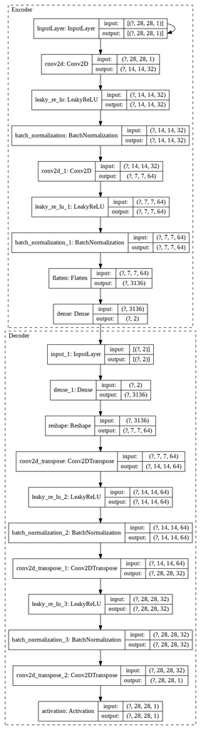

```python
model_plot(model=conv_autoencoder, name='ConvolutionalAutoEncoder')
```

#### Compiling Model

```python
conv_autoencoder.compile(optimizer=tf.keras.optimizers.Adam(learning_rate=learning_rate), loss='mse')
```

#### Training Model

```python
history2 = conv_autoencoder.fit(
    x=x_train,
    y=x_train,
    batch_size=batch_size,
    steps_per_epoch=train_batch_size,
    epochs=epochs,
    validation_data=(x_test, x_test),
    validation_steps=test_batch_size,
    shuffle=True
)
```

#### Analyzing Model

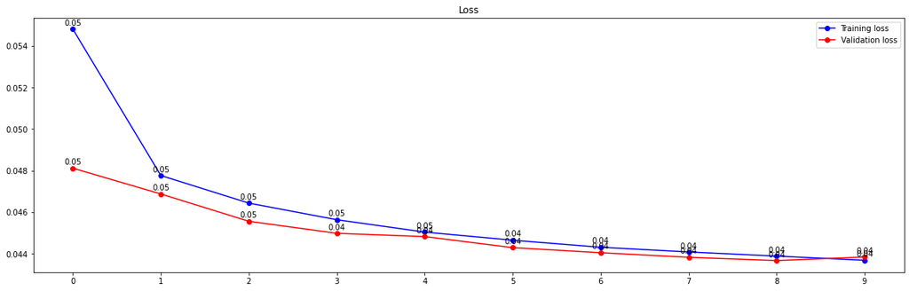

```python
plot_result(history=history2)
```

#### Testing Model

```python
pred2 = conv_autoencoder.predict(x=x_test)
pred2.shape
```

```
(10000, 28, 28, 1)
```

```python
metrics(x=x_test, y=pred2)
```

```
Mean Squared Error (MSE) = 0.04383893688213552
Universal Image Quality Index (UQI) = 0.5691873324675438
```

#### Visualizing Results

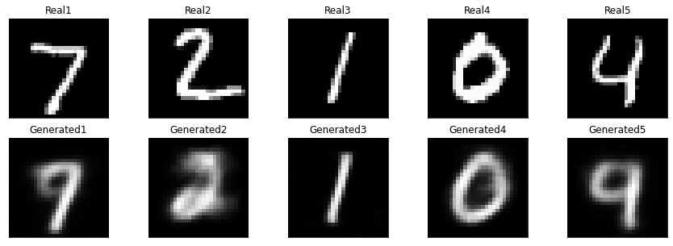

```python
visual_results(x=x_test, y=pred2, n=5, cmap='gray', size=(15, 5))
```

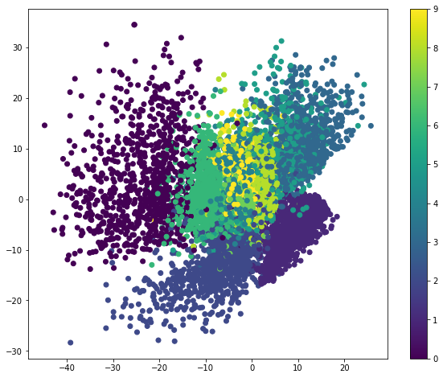

```python
visual_categorization(x=conv_encoder.predict(x=x_test), y=y_test)
```

#### Encoder-Decoder

```python
encodings = conv_encoder.predict(x=x_test)
encodings.shape
```

```
(10000, 2)
```

```python
output = conv_decoder.predict(x=encodings)
output.shape
```

```
(10000, 28, 28, 1)
```

### Sparse AutoEncoder

- Sparse autoencoders have hidden nodes greater than input nodes. They can still discover important features from the data.
- Sparsity constraint is introduced on the hidden layer. This is to prevent output layer copy input data.
- Sparse autoencoders have a sparsity penalty, Ω(h), a value close to zero but not zero. Sparsity penalty is applied on the hidden layer in addition to the reconstruction error. This prevents overfitting.
- We could, for example, add a **reguralization term** in the loss function. Doing this will make our autoencoder learn sparse representation of data.
- Another way is to take the highest activation values in the hidden layer and **zero out** the rest of the hidden nodes. This prevents autoencoders to use all of the hidden nodes at a time and forcing only a reduced number of hidden nodes to be used.
- As we activate and inactivate hidden nodes for each row in the dataset. Each hidden node extracts a feature from the data

[figure not shown]

- The model architecture remains the same as **Vanilla AutoEncoder** architecture.
- But, we just add a **L1 Regularization term**.

#### Defining Model

```python
class Encoder(tf.keras.layers.Layer):
    '''
        Encoder for Sparse AutoEncoder
        It instantiates tf.keras.layers.Layer
    '''

    def __init__(self, intermediate_dim, original_dim):
        super(Encoder, self).__init__(dtype='float32', name='Encoder')
        # self.encoder_input = tf.keras.Input(shape=original_dim, dtype='float32')
        self.hidden_layer = tf.keras.layers.Dense(
            units=intermediate_dim,
            activation='relu',
            activity_regularizer=tf.keras.regularizers.l1(10e-5),
            input_dim=original_dim
        )


    def call(self, input_features):
        '''
            Feeds input-data to the encoder
        '''
        return self.hidden_layer(input_features)
```

```python
class Decoder(tf.keras.layers.Layer):
    '''
        Decoder for Sparse AutoEncoder
        It instantiates tf.keras.layers.Layer
    '''

    def __init__(self, intermediate_dim, original_dim):
        super(Decoder, self).__init__(dtype='float32', name='Decoder')
        # self.decoder_input = tf.keras.Input(shape=intermediate_dim, dtype='float32')
        self.output_layer = tf.keras.layers.Dense(
            units=original_dim,
            activation='sigmoid',
            input_dim=intermediate_dim
        )


    def call(self, coded_features):
        '''
            Feeds input-data to the decoder
        '''
        return self.output_layer(coded_features)
```

```python
class SparseAutoEncoder(tf.keras.Model):
    '''Sparse AutoEncoder Architecture'''

    def __init__(self, intermediate_dim, original_dim):
        '''
            Input: intermediate_dim => Bottleneck Dimension
                   original_dim => Input Dimension
            Output: It creates the architecture based on inputs
        '''
        super(SparseAutoEncoder, self).__init__(name='SparseAutoEncoder', dtype='float32')
        self.encoder = Encoder(intermediate_dim=intermediate_dim, original_dim=original_dim)
        self.decoder = Decoder(intermediate_dim=intermediate_dim, original_dim=original_dim)

        super(SparseAutoEncoder, self).build((None, original_dim))


    def call(self, input_features):
        '''
            Feeds input-data to the model architecture
        '''
        coded_features = self.encoder(input_features)
        reconstructed_input = self.decoder(coded_features)
        return reconstructed_input
```

#### Initializing Model

```python
# selecting intermediate nodes more than input nodes
sparse_autoencoder = SparseAutoEncoder(
    intermediate_dim=high_intermediate_dim,
    original_dim=flat_x_train.shape[-1]
)
sparse_autoencoder.summary()
```

```
Model: "SparseAutoEncoder"
_________________________________________________________________
Layer (type)                 Output Shape              Param #
=================================================================
Encoder (Encoder)            multiple                  628000
_________________________________________________________________
Decoder (Decoder)            multiple                  627984
=================================================================
Total params: 1,255,984
Trainable params: 1,255,984
Non-trainable params: 0
_________________________________________________________________
```

```python
sparse_autoencoder.encoder.submodules
```

```
(<tensorflow.python.keras.layers.core.Dense at 0x7fc78ab6ed68>,)
```

```python
sparse_autoencoder.decoder.submodules
```

```
(<tensorflow.python.keras.layers.core.Dense at 0x7fc78a8800b8>,)
```

#### Compiling Model

```python
sparse_autoencoder.compile(optimizer='adam', loss='binary_crossentropy')
```

#### Training Model

```python
history3 = sparse_autoencoder.fit(
    x=flat_x_train,
    y=flat_x_train,
    epochs=epochs,
    batch_size=batch_size,
    steps_per_epoch=train_batch_size,
    validation_data=(flat_x_test, flat_x_test),
    validation_steps=test_batch_size,
    shuffle=True
)
```

#### Analyzing Model

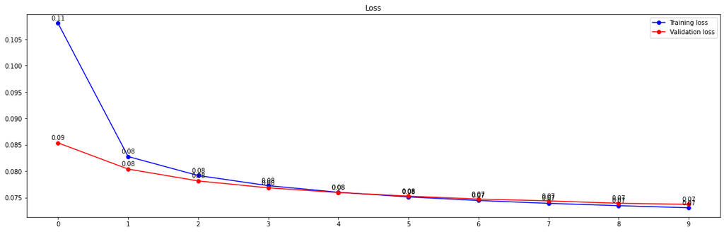

```python
plot_result(history=history3)
```

#### Testing Model

```python
pred3 = sparse_autoencoder.predict(flat_x_test).reshape(x_test.shape)
pred3.shape
```

```
(10000, 28, 28, 1)
```

```python
metrics(x=x_test, y=pred3)
```

```
Mean Squared Error (MSE) = 0.0023778319066617244
Universal Image Quality Index (UQI) = 0.8524306713460236
```

#### Visualizing Results

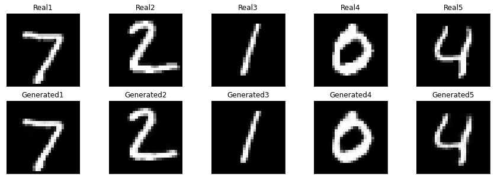

```python
visual_results(x=x_test, y=pred3, n=5, cmap='gray', size=(15, 5))
```

#### Encoder-Decoder

```python
encodings = sparse_autoencoder.encoder(flat_x_test)
encodings = np.array(encodings)
encodings.shape
```

```
(10000, 800)
```

```python
output = sparse_autoencoder.decoder(encodings)
output = np.array(output)
output.shape
```

```
(10000, 784)
```

```python
output = output.reshape(x_test.shape)
output.shape
```

```
(10000, 28, 28, 1)
```

### Denoising AutoEncoder

- Denoising autoencoders add some noise to the input image and learn to remove it. Thus avoiding to copy the input to the output without learning features about the data. These autoencoders take a partially corrupted input while training to recover the original undistorted input.
- The model learns a vector field for mapping the input data towards a lower-dimensional manifold which describes the natural data to cancel out the added noise. By this means, the encoder will extract the most important features and learn a more robust representation of the data.

[figure not shown]

- The model architecture remains the same as **Convolutional AutoEncoder** architecture.
- But, here we will be building architecture slightly different from before.
- Input images fed to the model are noisy.

#### Defining Model

```python
class DenoisingAutoEncoder:
    '''Denoising/Convolutional AutoEncoder Architecture'''

    @staticmethod
    def build(latent_dim, original_dim, filters=(32, 64)):
        '''
            Input: latent_dim => Bottleneck Dimension
                   original_dim => Input Dimension
                   filters => list of filters for Conv2D layer
            Output: It creates the architecture based on inputs
        '''

        # define the input to the encoder
        encoder_input = tf.keras.Input(shape=original_dim)
        x = encoder_input

        # loop over the number of filters
        for f in filters:
            # apply a CONV => RELU => BN operation
            x = tf.keras.layers.Conv2D(filters=f, kernel_size=(3, 3), padding='same', activation='relu')(x)
            x = tf.keras.layers.MaxPool2D(pool_size=(2, 2), padding='same')(x)

        # flatten the network and then construct our latent vector
        volumeSize = x.shape
        x = tf.keras.layers.Flatten()(x)
        latent = tf.keras.layers.Dense(units=latent_dim)(x)

        # build the encoder model
        encoder = tf.keras.Model(encoder_input, latent, name='Encoder')

        ###########################################################################################

        # define the input to the decoder
        latent_input = tf.keras.Input(shape=latent_dim)
        x = tf.keras.layers.Dense(np.prod(volumeSize[1:]))(latent_input)
        x = tf.keras.layers.Reshape((volumeSize[1], volumeSize[2], volumeSize[3]))(x)

        # loop over the number of filters in reverse order
        for f in filters[::-1]:
            # apply a CONV_TRANSPOSE => RELU => BN operation
            x = tf.keras.layers.Conv2D(filters=f, kernel_size=(3, 3), padding='same', activation='relu')(x)
            x = tf.keras.layers.UpSampling2D(size=(2, 2))(x)

        # apply a single CONV_TRANSPOSE layer used to recover the original depth of the image
        x = tf.keras.layers.Conv2DTranspose(filters=original_dim[-1], kernel_size=(3, 3), padding="same")(x)
        output = tf.keras.layers.Activation("sigmoid")(x)

        # build the encoder model
        decoder = tf.keras.Model(latent_input, output, name='Decoder')

        ###########################################################################################

        # our autoencoder is the encoder + decoder
        autoencoder = tf.keras.Model(encoder_input, decoder(encoder(encoder_input)), name="DenoisingAutoEncoder")

        # return a 3-tuple of the encoder, decoder, and autoencoder
        return (encoder, decoder, autoencoder)
```

#### Preparing Data for Model

- Here's how we will generate synthetic noisy digits: we just apply a gaussian noise matrix and clip the images between 0 and 1.

```python
noise_factor = 0.5
x_train_noisy = x_train + noise_factor * np.random.normal(loc=0.0, scale=1.0, size=x_train.shape)
x_test_noisy = x_test + noise_factor * np.random.normal(loc=0.0, scale=1.0, size=x_test.shape)

x_train_noisy = np.clip(x_train_noisy, 0., 1.)
x_test_noisy = np.clip(x_test_noisy, 0., 1.)
```

#### Initializing Model

```python
dconv_encoder, dconv_decoder, dconv_autoencoder = DenoisingAutoEncoder.build(
    latent_dim=intermediate_dim,
    original_dim=x_train_noisy.shape[1:]
)
```

```python
dconv_autoencoder.summary()
```

```
Model: "DenoisingAutoEncoder"
_________________________________________________________________
Layer (type)                 Output Shape              Param #
=================================================================
input_2 (InputLayer)         [(None, 28, 28, 1)]       0
_________________________________________________________________
Encoder (Model)              (None, 2)                 25090
_________________________________________________________________
Decoder (Model)              (None, 28, 28, 1)         65089
=================================================================
Total params: 90,179
Trainable params: 90,179
Non-trainable params: 0
_________________________________________________________________
```

```python
dconv_encoder.summary()
```

```
Model: "Encoder"
_________________________________________________________________
Layer (type)                 Output Shape              Param #
=================================================================
input_2 (InputLayer)         [(None, 28, 28, 1)]       0
_________________________________________________________________
conv2d_2 (Conv2D)            (None, 28, 28, 32)        320
_________________________________________________________________
max_pooling2d (MaxPooling2D) (None, 14, 14, 32)        0
_________________________________________________________________
conv2d_3 (Conv2D)            (None, 14, 14, 64)        18496
_________________________________________________________________
max_pooling2d_1 (MaxPooling2 (None, 7, 7, 64)          0
_________________________________________________________________
flatten_1 (Flatten)          (None, 3136)              0
_________________________________________________________________
dense_8 (Dense)              (None, 2)                 6274
=================================================================
Total params: 25,090
Trainable params: 25,090
Non-trainable params: 0
_________________________________________________________________
```

```python
dconv_decoder.summary()
```

```
Model: "Decoder"
_________________________________________________________________
Layer (type)                 Output Shape              Param #
=================================================================
input_3 (InputLayer)         [(None, 2)]               0
_________________________________________________________________
dense_9 (Dense)              (None, 3136)              9408
_________________________________________________________________
reshape_1 (Reshape)          (None, 7, 7, 64)          0
_________________________________________________________________
conv2d_4 (Conv2D)            (None, 7, 7, 64)          36928
_________________________________________________________________
up_sampling2d (UpSampling2D) (None, 14, 14, 64)        0
_________________________________________________________________
conv2d_5 (Conv2D)            (None, 14, 14, 32)        18464
_________________________________________________________________
up_sampling2d_1 (UpSampling2 (None, 28, 28, 32)        0
_________________________________________________________________
conv2d_transpose_3 (Conv2DTr (None, 28, 28, 1)         289
_________________________________________________________________
activation_1 (Activation)    (None, 28, 28, 1)         0
=================================================================
Total params: 65,089
Trainable params: 65,089
Non-trainable params: 0
_________________________________________________________________
```

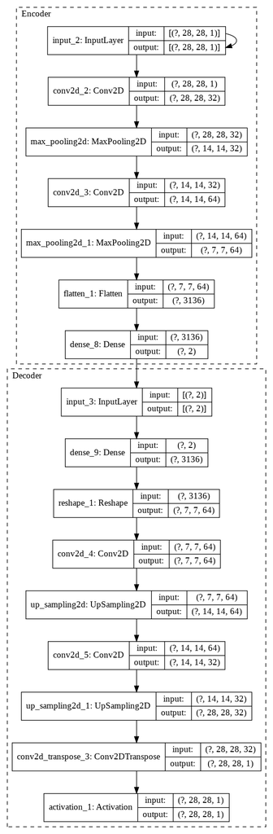

```python
model_plot(model=dconv_autoencoder, name='DenoisingAutoEncoder')
```

#### Compiling Model

```python
dconv_autoencoder.compile(optimizer=tf.keras.optimizers.Adam(learning_rate=learning_rate), loss='binary_crossentropy')
```

#### Training Model

```python
history4 = dconv_autoencoder.fit(
    x=x_train_noisy,
    y=x_train,
    batch_size=batch_size,
    steps_per_epoch=train_batch_size,
    epochs=epochs,
    validation_data=(x_test_noisy, x_test),
    validation_steps=test_batch_size,
    shuffle=True
)
```

#### Analyzing Model

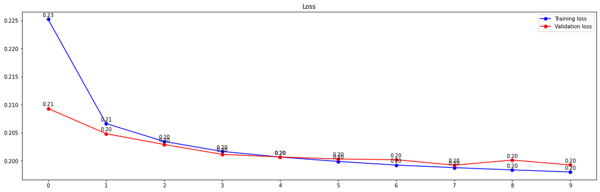

```python
plot_result(history=history4)
```

#### Testing Model

```python
pred4 = dconv_autoencoder.predict(x=x_test_noisy)
pred4.shape
```

```
(10000, 28, 28, 1)
```

```python
metrics(x=x_test, y=pred4)
```

```
Mean Squared Error (MSE) = 0.04642460561161736
Universal Image Quality Index (UQI) = 0.5591388014164959
```

#### Visualizing Results

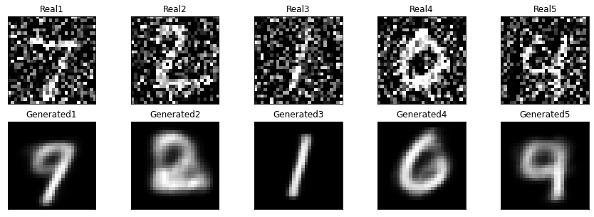

```python
visual_results(x=x_test_noisy, y=pred4, n=5, cmap='gray', size=(15, 5))
```

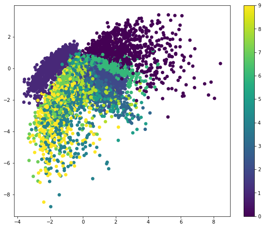

```python
visual_categorization(x=dconv_encoder.predict(x=x_test_noisy), y=y_test)
```

#### Encoder-Decoder

```python
encodings = dconv_encoder.predict(x=x_test_noisy)
encodings.shape
```

```
(10000, 2)
```

```python
output = dconv_decoder.predict(x=encodings)
output.shape
```

```
(10000, 28, 28, 1)
```

### Contractive AutoEncoder

- The objective of a contractive autoencoder is to have a robust learned representation which is less sensitive to small variation in the data. Robustness of the representation for the data is done by applying a penalty term to the loss function.
- Contractive autoencoder is another regularization technique just like sparse and denoising autoencoders. However, this regularizer corresponds to the **Frobenius norm of the Jacobian matrix** of the encoder activations with respect to the input. Frobenius norm of the Jacobian matrix for the hidden layer is calculated with respect to input and it is basically the sum of square of all elements.
- Contractive autoencoder is a better choice than denoising autoencoder to learn useful feature extraction.

[figure not shown]

- The model architecture remains the same as **Vanilla AutoEncoder** architecture.
- But, loss function is different from before.

#### Defining Loss Function

```python
def contractive_loss(model, lambda_param):

    def loss(y_pred, y_true):
        mse = tf.reduce_mean(tf.square(y_true - y_pred), axis=1)

        W = model.encoder.weights[0]  # N x N_hidden
        W = tf.transpose(W)           # N_hidden x N
        h = model.encoder(y_true)
        dh = h * (1 - h)              # N_batch x N_hidden

        # N_batch x N_hidden * N_hidden x 1 = N_batch x 1
        contractive = lambda_param*tf.reduce_sum(tf.square(dh)*tf.reduce_sum(tf.square(W), axis=1), axis=1)

        return mse + contractive

    return loss
```

#### Initializing Model

```python
# using VanillaAutoEncoder & selecting intermediate nodes more than input nodes
contractive_autoencoder = VanillaAutoEncoder(
    intermediate_dim=high_intermediate_dim,
    original_dim=flat_x_train.shape[-1]
)
```

#### Compiling Model

```python
contractive_autoencoder.compile(
    optimizer=tf.keras.optimizers.Adam(learning_rate=learning_rate),
    loss=contractive_loss(model=contractive_autoencoder, lambda_param=1e-4)
)
```

#### Training Model

```python
history5 = contractive_autoencoder.fit(
    x=flat_x_train,
    y=flat_x_train,
    batch_size=batch_size,
    epochs=epochs,
    steps_per_epoch=train_batch_size,
    validation_data=(flat_x_test, flat_x_test),
    validation_steps=test_batch_size,
    shuffle=True
)
```

#### Analyzing Model

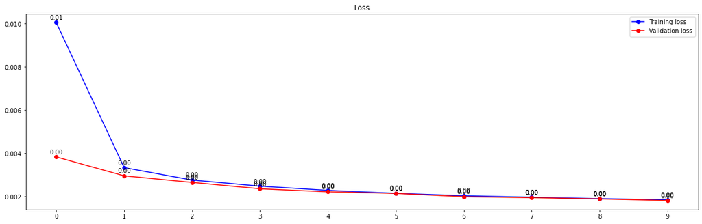

```python
plot_result(history=history5)
```

#### Testing Model

```python
pred5 = contractive_autoencoder.predict(x=flat_x_test).reshape(x_test.shape)
pred5.shape
```

```
(10000, 28, 28, 1)
```

```python
metrics(x=x_test, y=pred5)
```

```
Mean Squared Error (MSE) = 0.0013270319610606599
Universal Image Quality Index (UQI) = 0.8516250635103024
```

#### Visualizing Results

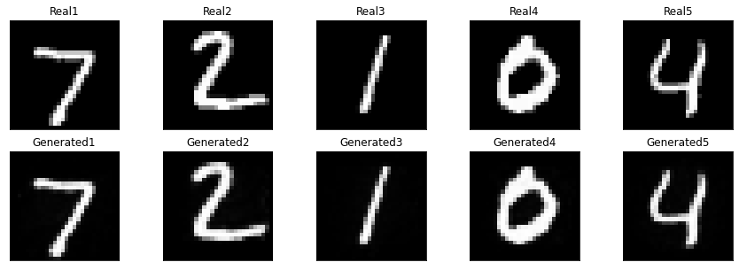

```python
visual_results(x=x_test, y=pred5, n=5, cmap='gray', size=(15, 5))
```

#### Encoder-Decoder

```python
encodings = contractive_autoencoder.encoder.predict(x=flat_x_test)
encodings.shape
```

```
(10000, 800)
```

```python
output = contractive_autoencoder.decoder.predict(x=encodings)
output.shape
```

```
(10000, 784)
```

```python
output = output.reshape(x_test.shape)
output.shape
```

```
(10000, 28, 28, 1)
```

### Variational AutoEncoder (VAE)

- VAE is a probabilistic take on the autoencoder, a model which takes high dimensional input data compress it into a smaller representation.
- This type of autoencoder can generate new images just like GANs.
- Unlike a traditional autoencoder, which maps the input onto a latent vector, a VAE maps the input data into the parameters of a probability distribution, such as the mean and variance of a Gaussian.
- They use a variational approach for latent representation learning, which results in an additional loss component and a specific estimator for the training algorithm called the **Stochastic Gradient Variational Bayes** estimator.
- The probability distribution of the latent vector of a variational autoencoder typically matches the training data much closer than a standard autoencoder.
- This approach produces a continuous, structured latent space, which is useful for image generation.
- As VAEs are much more flexible and customisable in their generation behaviour than GANs, they are suitable for art generation of any kind.

[figure not shown]

#### Defining Model

```python
class VAE(tf.keras.Model):
    '''Variational AutoEncoder'''

    def __init__(self, latent_dim, original_dim, batch_size, intermediate_dim=512):
        '''
            Input: latent_dim => Bottleneck Dimension
                   original_dim => Input Dimension
                   batch_size => fix size of batches of input
                   intermediate_dim => Hidden Layer Dimension
            Output: It creates the architecture based on inputs
        '''
        super(VAE, self).__init__(name='VAE')
        self.batch_size = batch_size

        # Q(z|X) -- encoder
        self.encoder = tf.keras.Sequential([
            tf.keras.layers.Dense(units=intermediate_dim, activation='relu', input_dim=original_dim, name='Intermediate'),
            tf.keras.layers.Dense(units=2*latent_dim, activation='linear', name='Latent')
        ], name='Encoder')

        # P(X|z) -- decoder
        self.decoder = tf.keras.Sequential([
            tf.keras.layers.Dense(units=intermediate_dim, activation='relu', input_dim=latent_dim, name='Intermediate'),
            tf.keras.layers.Dense(units=original_dim, activation='sigmoid', name='Output')
        ], name='Decoder')

        super(VAE, self).build((None, original_dim))


    def encode(self, input_features):
        '''
           passes input to encoder & it's output gets splits into mean and logvar
        '''
        mean, logvar = tf.split(self.encoder(input_features), num_or_size_splits=2, axis=1)
        return mean, logvar


    # Sample z ~ Q(z|X)
    def sample_z(self, mean, logvar):
        '''
            samples z from z_mean and z_log_var
        '''
        eps = tf.random.normal(shape=(self.batch_size, mean.shape[-1]))
        return mean + tf.exp(logvar * .5) * eps                                # z = z_mean + exp(z_log_var)*epsilon


    def decode(self, z):
        '''
            returns decoder's output
        '''
        return self.decoder(z)


    def call(self, input_features):
        '''
            Feeds input-data to the model architecture
        '''
        mean, logvar = self.encode(input_features)
        z = self.sample_z(mean, logvar)
        return self.decode(z)
```

#### Defining Loss Function

```python
def vae_loss(model):
    '''Calculate loss = reconstruction loss + KL loss for each data in minibatch'''

    def loss(y_true, y_pred):
        mean, logvar = model.encode(y_true)

        # E[log P(X|z)]
        cross_ent = tf.nn.sigmoid_cross_entropy_with_logits(logits=y_pred, labels=y_true)
        logpx_z = tf.reduce_sum(cross_ent, axis=1)

        # D_KL(Q(z|X) || P(z|X)); calculate in closed form as both dist. are Gaussian
        kl_loss = - 0.5 * tf.reduce_mean(1 + logvar - tf.square(mean) - tf.exp(logvar), axis=-1)

        return logpx_z + kl_loss

    return loss
```

#### Initializing Model

```python
vae = VAE(
    latent_dim=intermediate_dim,
    original_dim=flat_x_train.shape[-1],
    batch_size=batch_size,
    intermediate_dim=512
)
vae.summary()
```

```
Model: "VAE"
_________________________________________________________________
Layer (type)                 Output Shape              Param #
=================================================================
Encoder (Sequential)         (None, 4)                 403972
_________________________________________________________________
Decoder (Sequential)         (None, 784)               403728
=================================================================
Total params: 807,700
Trainable params: 807,700
Non-trainable params: 0
_________________________________________________________________
```

```python
vae.encoder.summary()
```

```
Model: "Encoder"
_________________________________________________________________
Layer (type)                 Output Shape              Param #
=================================================================
Intermediate (Dense)         (None, 512)               401920
_________________________________________________________________
Latent (Dense)               (None, 4)                 2052
=================================================================
Total params: 403,972
Trainable params: 403,972
Non-trainable params: 0
_________________________________________________________________
```

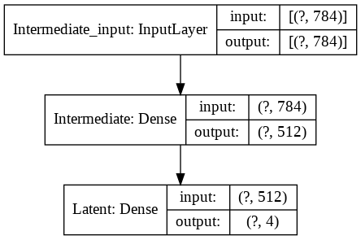

```python
model_plot(model=vae.encoder, name='VariationalAutoEncoder-Encoder')
```

```python
vae.decoder.summary()
```

```
Model: "Decoder"
_________________________________________________________________
Layer (type)                 Output Shape              Param #
=================================================================
Intermediate (Dense)         (None, 512)               1536
_________________________________________________________________
Output (Dense)               (None, 784)               402192
=================================================================
Total params: 403,728
Trainable params: 403,728
Non-trainable params: 0
_________________________________________________________________
```

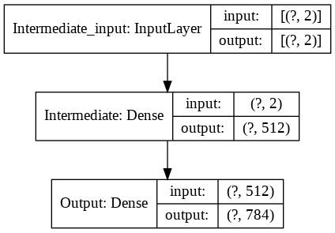

```python
model_plot(model=vae.decoder, name='VariationalAutoEncoder-Decoder')
```

#### Compiling Model

```python
vae.compile(
    optimizer=tf.keras.optimizers.Adam(learning_rate=learning_rate),
    loss=vae_loss(model=vae)
)
```

#### Preparing Data for Model

- Since 10000/batch_size(=32)=312.5 (fraction i.e., last batch will be that 0.5~16 samples<batch_size)
- Below code will throw an error as we are using batch_size as a parameter in our model
- Hence, we have to pass exactly batch_size examples into the model

```python
batch_test_size = (test_size//batch_size)*batch_size
batch_train_size = (train_size//batch_size)*batch_size
```

```python
flat_x_train_batch = flat_x_train[:batch_train_size]
flat_x_test_batch = flat_x_test[:batch_test_size]
```

#### Training Model

```python
history8 = vae.fit(
    x=flat_x_train_batch,
    y=flat_x_train_batch,
    batch_size=batch_size,
    steps_per_epoch=train_batch_size,
    epochs=epochs,
    validation_data=(flat_x_test_batch, flat_x_test_batch),
    validation_steps=test_batch_size,
    shuffle=True
)
```

#### Analyzing Model

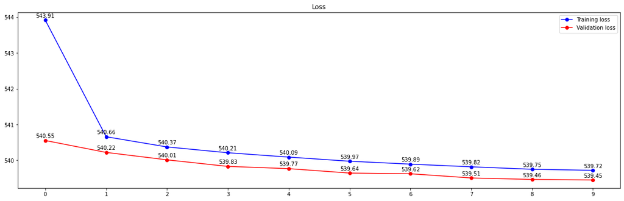

```python
plot_result(history=history8)
```

#### Testing Model

```python
pred8 = vae.predict(x=flat_x_test_batch, batch_size=batch_size).reshape((batch_test_size, *x_test.shape[1:]))
pred8.shape
```

```
(9984, 28, 28, 1)
```

```python
metrics(x=x_test[:batch_test_size], y=pred8)
```

```
Mean Squared Error (MSE) = 0.08738351761010477
Universal Image Quality Index (UQI) = 0.1959109597391534
```

#### Visualizing Model

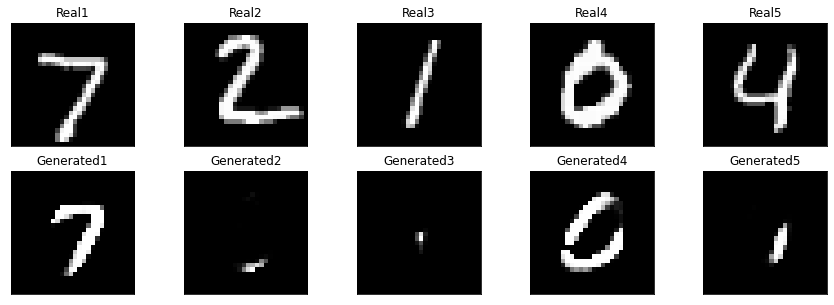

```python
visual_results(x=x_test[:batch_test_size], y=pred8, n=5, cmap='gray', size=(15, 5))
```

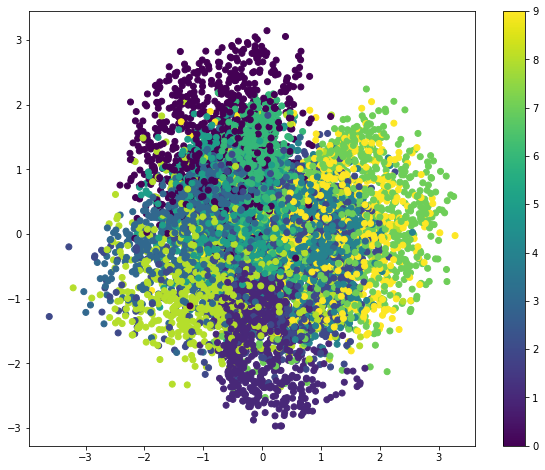

```python
visual_categorization(x=vae.encoder.predict(x=flat_x_test_batch, batch_size=batch_size), y=y_test[:batch_test_size])
```

#### Encoder-Decoder

```python
encodings = np.array(vae.encode(input_features=flat_x_test_batch)[0])
encodings.shape
```

```
(9984, 2)
```

```python
output = np.array(vae.decode(z=encodings))
output.shape
```

```
(9984, 784)
```

```python
output = output.reshape((batch_test_size, *x_test.shape[1:]))
output.shape
```

```
(9984, 28, 28, 1)
```

### Convolutional Variational AutoEncoder

[figure not shown]

- The model architecture is the same as **Variational AutoEncoder** architecture.
- But, instead of just Dense layers, **Conv layers** are also used.

#### Defining Model

```python
class CVAE(tf.keras.Model):
    """Convolutional Variational AutoEncoder"""

    def __init__(self, latent_dim):
        super(CVAE, self).__init__(name='CVAE')
        self.latent_dim = latent_dim

        self.encoder = tf.keras.Sequential([
                tf.keras.layers.InputLayer(input_shape=(28, 28, 1)),
                tf.keras.layers.Conv2D(filters=32, kernel_size=3, strides=(2, 2), activation='relu'),
                tf.keras.layers.Conv2D(filters=64, kernel_size=3, strides=(2, 2), activation='relu'),
                tf.keras.layers.Flatten(),
                # No activation
                tf.keras.layers.Dense(latent_dim + latent_dim)    # 2 times latent_dim => for mean & log_var each
        ], name='Encoder')

        self.decoder = tf.keras.Sequential([
                tf.keras.layers.InputLayer(input_shape=(latent_dim,)),
                tf.keras.layers.Dense(units=7*7*32, activation=tf.nn.relu),
                tf.keras.layers.Reshape(target_shape=(7, 7, 32)),
                tf.keras.layers.Conv2DTranspose(filters=64, kernel_size=3, strides=2, padding='same', activation='relu'),
                tf.keras.layers.Conv2DTranspose(filters=32, kernel_size=3, strides=2, padding='same', activation='relu'),
                # No activation
                tf.keras.layers.Conv2DTranspose(filters=1, kernel_size=3, strides=1, padding='same')
        ], name='Decoder')


    @tf.function
    def sample(self, eps=None):
        if eps is None:
            eps = tf.random.normal(shape=(100, self.latent_dim))
        return self.decode(eps, apply_sigmoid=True)


    def encode(self, x):
        mean, logvar = tf.split(self.encoder(x), num_or_size_splits=2, axis=1)
        return mean, logvar


    def reparameterize(self, mean, logvar):
        eps = tf.random.normal(shape=mean.shape)
        return eps * tf.exp(logvar * .5) + mean    # z = z_mean + exp(z_log_var)*epsilon


    def decode(self, z, apply_sigmoid=False):
        logits = self.decoder(z)
        if apply_sigmoid:
            probs = tf.sigmoid(logits)
            return probs
        return logits
```

#### Defining Loss Function

```python
def log_normal_pdf(sample, mean, logvar, raxis=1):
    log2pi = tf.math.log(2. * np.pi)
    return tf.reduce_sum(-.5 * ((sample - mean) ** 2. * tf.exp(-logvar) + logvar + log2pi), axis=raxis)


def compute_loss(model, x):
    mean, logvar = model.encode(x)
    z = model.reparameterize(mean, logvar)
    x_logit = model.decode(z)

    # log[P(X|z)]
    cross_ent = tf.nn.sigmoid_cross_entropy_with_logits(logits=x_logit, labels=x)
    logpx_z = -tf.reduce_sum(cross_ent, axis=[1, 2, 3])

    # log[P(z)]
    logpz = log_normal_pdf(z, 0., 0.)

    # log[Q(z|x)]
    logqz_x = log_normal_pdf(z, mean, logvar)

    # log[P(X|z)] + log[P(z)] - log[Q(z|x)]
    return -tf.reduce_mean(logpx_z + logpz - logqz_x)
```

#### Defining Optimizer

```python
optimizer = tf.keras.optimizers.Adam(1e-4)
```

#### Defining Training Process

```python
# @tf.function
def train_step(model, x, optimizer):
    """Executes one training step and returns the loss.

    This function computes the loss and gradients, and uses the latter to
    update the model's parameters.
    """
    with tf.GradientTape() as tape:
        loss = compute_loss(model, x)

    gradients = tape.gradient(loss, model.trainable_variables)
    optimizer.apply_gradients(zip(gradients, model.trainable_variables))
```

#### Preparing Data for Model

```python
conv_train_dataset = (tf.data.Dataset.from_tensor_slices(x_train).shuffle(train_size).batch(batch_size))
conv_test_dataset = (tf.data.Dataset.from_tensor_slices(x_test).shuffle(test_size).batch(batch_size))
```

#### Defining some more HyperParameters

```python
# set the dimensionality of the latent space to a plane for visualization later
latent_dim = 2
num_examples_to_generate = 16

# keeping the random vector constant for generation (prediction) so
# it will be easier to see the improvement.
random_vector_for_generation = tf.random.normal(shape=[num_examples_to_generate, latent_dim])
```

#### Initializing Model

```python
model = CVAE(latent_dim)
```

#### Generating Images

```python
def generate_and_save_images(model, epoch, test_sample):
    mean, logvar = model.encode(test_sample)
    z = model.reparameterize(mean, logvar)
    predictions = model.sample(z)
    fig = plt.figure(figsize=(4, 4))

    for i in range(predictions.shape[0]):
        plt.subplot(4, 4, i+1)
        plt.imshow(predictions[i, :, :, 0], cmap='gray')
        plt.axis('off')

    # tight_layout minimizes the overlap between 2 sub-plots
    plt.savefig('image_at_epoch_{:04d}.png'.format(epoch))
```

```python
# Pick a sample of the test set for generating output images
assert batch_size >= num_examples_to_generate
for test_batch in conv_test_dataset.take(1):
    test_sample = test_batch[0:num_examples_to_generate, :, :, :]
```

#### Training Model

```
Epoch: 1, Test set ELBO: -180.88746643066406, time elapse for current epoch: 28.962015390396118
Epoch: 2, Test set ELBO: -172.28163146972656, time elapse for current epoch: 28.67097568511963
Epoch: 3, Test set ELBO: -168.34156799316406, time elapse for current epoch: 28.458841800689697
Epoch: 4, Test set ELBO: -165.945556640625, time elapse for current epoch: 28.43031644821167
Epoch: 5, Test set ELBO: -164.09564208984375, time elapse for current epoch: 28.48192310333252
Epoch: 6, Test set ELBO: -162.7935028076172, time elapse for current epoch: 28.54286241531372
Epoch: 7, Test set ELBO: -162.0579071044922, time elapse for current epoch: 28.712969064712524
Epoch: 8, Test set ELBO: -160.97694396972656, time elapse for current epoch: 28.739367961883545
Epoch: 9, Test set ELBO: -160.4205322265625, time elapse for current epoch: 28.356358528137207
Epoch: 10, Test set ELBO: -160.01776123046875, time elapse for current epoch: 28.64175844192505
```

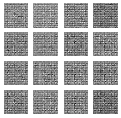

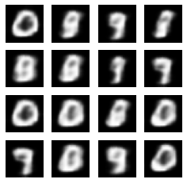

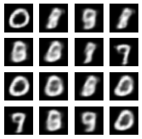

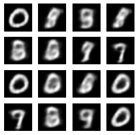

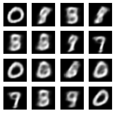

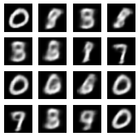

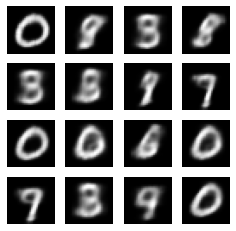

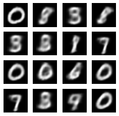

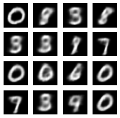

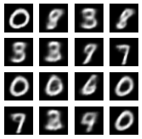

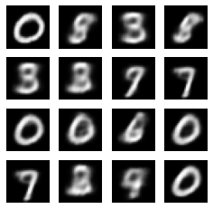

```python
generate_and_save_images(model, 0, test_sample)

for epoch in range(1, epochs + 1):
    start_time = time.time()
    for train_x in conv_train_dataset:
        train_step(model, train_x, optimizer)
    end_time = time.time()

    loss = tf.keras.metrics.Mean()
    for test_x in conv_test_dataset:
        loss(compute_loss(model, test_x))

    elbo = -loss.result()
    # IPython.display.clear_output(wait=False)
    print('Epoch: {}, Test set ELBO: {}, time elapse for current epoch: {}'.format(epoch, elbo, end_time - start_time))
    generate_and_save_images(model, epoch, test_sample)
```